# Nonparametric Tests

# Departure from Normality Assumptions

- **Departure from Normality**: Occurs when the sample suggests that the population does not follow a normal distribution.
- **Consequences**:
  - Can affect the validity of statistical tests (e.g., t-tests).
  - May lead to incorrect conclusions.
- **Common Causes of Departure:**
  - **Skewness**: Asymmetry in the distribution.
  - **Kurtosis**: Peakedness or flatness compared to a normal distribution.

# Example

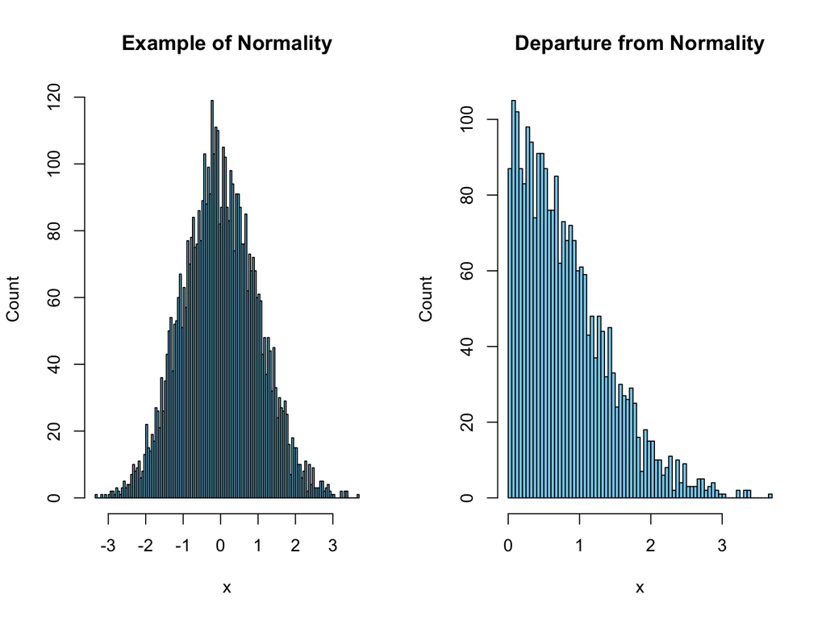

# Non parametric Methods

- **Definition**: Statistical methods that do not assume a specific distribution for the population.
- **Difference from Parametric Methods**:
  - **Parametric**:
    - Assumes data follows a known distribution (e.g., normal, $t$, etc.).
    - Estimates the parameter of the distribution (e.g., $\mu, \sigma^2$ for normal).
    - We estimate the population parameter first, then estimate other unknown quantities (e.g., median in normal).
  - **Nonparametric**:
    - Makes no such assumptions about the underlying data distribution.
    - It still has parameters to be estimated.
    - Sample estimates are usually good candidates for equivalent population parameters.

# Examples of Usage of Nonparametric Methods

- **Small Sample Sizes**: When the sample size is too small to reliably estimate parameters.
- **Non-Normal Data**: When data significantly departs from normality.
- **Ordinal Data**: When dealing with ordinal data or ranks rather than interval data.

# Example:

- **Q: What are the estimates of mean, variance, and median for $\texttt{mpg}$ from $\texttt{mtcars}$ data i) Under normality? ii) Under nonparametric method?**

```r
data("mtcars")
MPG = mtcars$mpg
mean(MPG)
```

```
## [1] 20.09062
```

```r
var(MPG)
```

```
## [1] 36.3241
```

```r
median(MPG)
```

```
## [1] 19.2
```

# Cont.

1. **Under normality,**
1. Estimate of mean = 20.09062
2. Estimate of median = 20.09062
3. Estimate of variance = 36.3241
2. **In nonparametric method,**
1. Estimate of mean = 20.09062
2. Estimate of median = 19.2
3. Estimate of variance = 36.3241

# Necessary: Binomial Distribution

- Recall the coin toss example:
  1. I tossed a coin $n$ times and got $x$ many heads.
  2. Each event (toss) has two possible outcomes (here H/T).
  3. Different events (tosses) are independent.
- Define X = Number of heads out of $n$ tosses.
- We say $X \sim$ Binomial(n,p).
- If I toss a coin $n$ times, number of heads can be $0, 1, \ldots, n$.
- Probaility distribution: $\mathbb{P}(X = x)$ = $n \choose x$ $p^x (1-p)^{n-x}$
  - Note: $n \choose x$ = $\frac{n!}{x! (n-x)!}$

# Binomial probabilities

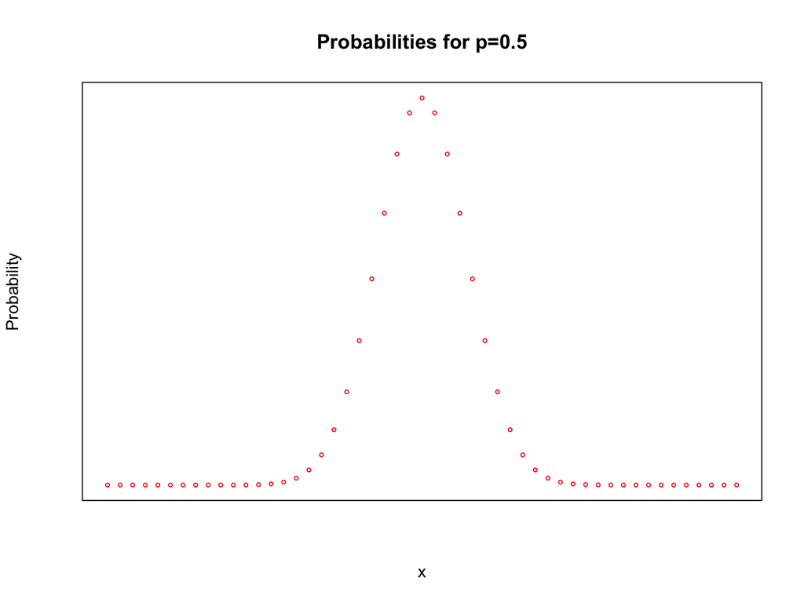

# Binomial probabilities

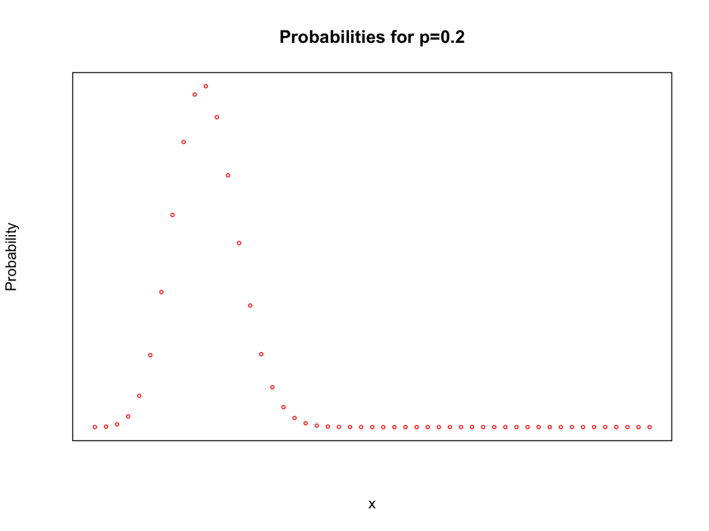

# Binomial probabilities

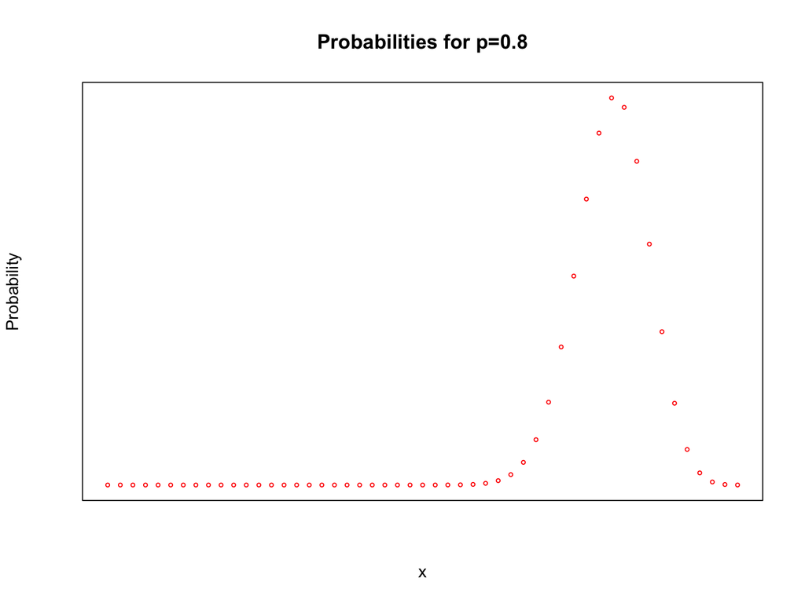

# Parametric and Non-parametric Tests

| **Test Type** | **Parametric Test** | **Nonparametric Test** |
| --- | --- | --- |
| **1-sample test** | One-sample t-test | Sign test |
| **2-sample test (paired)** | Paired t-test | Wilcoxon signed-rank test (for paired samples) |
| **2-sample test (unpaired)** | Two-sample t-test | Mann-Whitney U test (Wilcoxon rank-sum test) |

# Sign Test

- **Sign Test**: A nonparametric test used to evaluate if the **median** of a single sample differs from a hypothesized value.
- **Purpose**: Test if the population median of a sample $\mathrm{X}= \{x_1, \ldots, x_n \}$ is $\mu_0$.
- **Hypotheses**: $H_0$: M (median) = $\mu_0$; $H_1:$ M $\neq, \leq, or \geq$ $\mu_0$.

# Procedure

1. Assign a “plus”/success (+) to numbers $\geq$ $\mu_0$, a “minus”/failure otherwise.
- If $x_i > \mu_0$, it’s a + or success.
- If $x_i < \mu_0$, it’s a - or failure.
2. Test statistic: T = Total number of success
3. Under $H_0$, the number of **+** and **-** should be roughly equal, following a **binomial distribution** with probability $p = 0.5$. (Recall the head/tail count from coin toss example).
4. $p$ value = Probability that a Binomial(n, 0.5) variable is at least as extreme as T.
5. Reject $H_0$ if $p$ value < $\alpha$.

# Example: `mtcars` Dataset

**Let’s test if the median MPG from the $\texttt{mtcars}$ data is 18 or not.**

- $H_0$: M (Median mpg) = 18 vs $H_A$: M $\neq$ 18. Test at $\alpha = 0.05$.
- Data:

  21.0, 21.0, 22.8, 21.4, 18.7, 18.1, 14.3, 24.4, 22.8, 19.2, 17.8, 16.4, 17.3, 15.2, 10.4, 10.4, 14.7, 32.4, 30.4, 33.9, 21.5, 15.5, 15.2, 13.3, 19.2, 27.3, 26.0, 30.4, 15.8, 19.7, 15.0, 21.4
- Plus signs (19):

  21.0, 21.0, 22.8, 21.4, 18.7, 18.1, 24.4, 22.8, 19.2, 32.4, 30.4, 33.9, 21.5, 19.2, 27.3, 26.0, 30.4, 19.7, 21.4
- Minus signs (13):

  14.3, 17.8, 16.4, 17.3, 15.2, 10.4, 10.4, 14.7, 15.5, 15.2, 13.3, 15.8, 15.0
- Remaining part of the test will use the $\texttt{binom.test}$ function in $\texttt{R}$.

# $\texttt{R}$ syntax

```r
binom.test(<positives_count>, <total_count>, alternative = <alternative>, conf.level=<1-alpha>)
```

**Example**

```r
binom.test(19, 32, alternative = "two.sided", conf.level = 1-0.05)
```

```
##
##  Exact binomial test
##
## data:  19 and 32
## number of successes = 19, number of trials = 32, p-value = 0.3771
## alternative hypothesis: true probability of success is not equal to 0.5
## 95 percent confidence interval:
##  0.4064492 0.7630159
## sample estimates:
## probability of success
##                0.59375
```

# (Contd.)

```r
data(mtcars)
hypothised_median = 18
MPG = mtcars$mpg
positives_count   = sum(MPG > hypothised_median)
negatives_count   = sum(MPG < hypothised_median)
binom.test(positives_count, positives_count + negatives_count,
                    alternative = "two.sided", conf.level = 1-0.05)
```

```
##
##  Exact binomial test
##
## data:  positives_count and positives_count + negatives_count
## number of successes = 19, number of trials = 32, p-value = 0.3771
## alternative hypothesis: true probability of success is not equal to 0.5
## 95 percent confidence interval:
##  0.4064492 0.7630159
## sample estimates:
## probability of success
##                0.59375
```

# Decision

- p-value > $\alpha$, hence can not reject $H_0$.
- Alternatively, confidence interval for $p$ contains $0.5$. Hence can not reject $H_0$.

# Mann-Whitney Test / Wilcoxon Rank-Sum Test

- Equivalent of two sample independent $t$ test.
  - Group 1: $\mathrm{X}_1: \{x_{11}, x_{12}, \cdots, x_{1m} \}$.
  - Group 2: $\mathrm{X}_2: \{x_{21}, x_{22}, \cdots, x_{2n} \}$.
  - $H_0$: $M_1$ (Median of sample 1) = $M_2$ (Median of sample 2)
  - $H_A$: $M_1$ $\neq, \leq, or \geq$ $M_2$.

# Procedure

1. Combine both the samples together.
2. Rank them together. Smallest = Rank 1, largest = Rank (m + n).
3. S = Sum of ranks of sample 1.
4. For large samples, under $H_0$, S follows normal distirbution with mean $\mu_S = \frac{m(m+n+1)}{2}$, variance $\sigma^2_S = \frac{mn(m+n+1)}{12}$.
5. Test statistic 2: W = $\frac{S - \mu_S}{\sigma_S}$.
6. Reject if:
- $|W| > z_{\alpha/2}$ if $H_A: M_1 \neq M_2$
- $W \geq z_{\alpha}$ if $H_A: M_1 \geq M_2$
- $W \leq -z_{\alpha}$ if $H_A: M_1 \leq M_2$

# Example: Method of Ranking

- Group 1: $\{15, 20, 22, 21, 18 \}$.
- Group 2: $\{9, 16, 25, 12, 10, 11, 17, 8 \}$.
- **Step 1 : Combine together.**

  15, 20, 22, 21, 18, 9, 16, 25, 12, 10, 11, 17, 8
- **Step 2: Rank them** 6, 10, 12, 11, 9, 2, 7, 13, 5, 3, 4, 8, 1
- Sum of rank of sample 1: S = 48.

# Example from Last class

This table shows an example of heights of plants under two different fertilizers. Test if the new fertilizer is working better, i.e., average height under the new fertilizer is more than the earlier one.

Old fertilizer: **48.2, 54.6, 58.3, 47.8, 51.4, 52.0, 55.2, 49.1, 49.9, 52.6**

New fertilizer: **52.3, 57.4, 55.6, 53.2, 61.3, 58.0, 59.8, 54.8**

# Cont.

- $M_1$ = Median height under old fertilizer
- $M_2$ = Median height under new.
- $H_0$: $M_1 \geq M_2$.
- $H_A$: $M_1$ < $M_2$.
- Independent sample, one-sided test.

# $\texttt{R}$ syntax

Syntax:

```r
wilcox.test(<values> ~ <group>, conf.level = 1- <alpha>,
            mu = 0, alternative=<either of "two.sided", "less", or "greater">, exact=FALSE)
```

Example:

```r
height = c(48.2, 54.6, 58.3, 47.8, 51.4, 52.0, 55.2, 49.1, 49.9, 52.6,
           52.3, 57.4, 55.6, 53.2, 61.3, 58.0, 59.8, 54.8)
fertilizer = c(rep("1.Old", 10), rep("2.New", 8))
wilcox.test(height ~ fertilizer, conf.level = 1-0.05, mu = 0,
            alternative="less", exact=FALSE)
```

```
##
##  Wilcoxon rank sum test with continuity correction
##
## data:  height by fertilizer
## W = 12, p-value = 0.007274
## alternative hypothesis: true location shift is less than 0
```

# Wilcoxon Signed-Rank Test

- Equivalent of two sample paired $t$ test.

  - |  | Subject 1 | Subject 2 | $\ldots$ | Subject n |
    | --- | --- | --- | --- | --- |
    | **Variable 1** | $x_{11}$ | $x_{12}$ | $\ldots$ | $x_{1n}$ |
    | **Variable 2** | $x_{21}$ | $x_{22}$ | $\ldots$ | $x_{2n}$ |

  - $H_0$: $M_1$ (Median of variable 1) = $M_2$ (Median of variable 2)
  - $H_A$: $M_1$ $\neq, \leq, or \geq$ $M_2$.

# Procedure

1. Form the differences and signs:

|  | Subject 1 | Subject 2 | $\ldots$ | Subject n |
| --- | --- | --- | --- | --- |
| **Variable 1** | $x_{11}$ | $x_{12}$ | $\ldots$ | $x_{1n}$ |
| **Variable 2** | $x_{21}$ | $x_{22}$ | $\ldots$ | $x_{2n}$ |
| **Difference** | $d_1 = (x_{11} - x_{21}$) | $d_2 = (x_{12} - x_{22})$ | $\ldots$ | $d_n = (x_{1n} - x_{2n})$ |
| **Ranks** | $R_{1}$ | $R_{2}$ | $\ldots$ | $R_{n}$ |
| **Signs** | $S_1 = +1$ if $d_1 > 0$, -1 ow. | $S_2 = +1$ if $d_2 > 0$, -1 ow. | $\ldots$ | $S_n = +1$ if $d_n > 0$, -1 ow. |

2. Define $R_i$: Rank of the **absolute differences** $|d_i|$ in increasing order (lowest = 1 to highest = n).
3. Define $S_i$ = +1 if $d_i > 0$, -1 if $d_i < 0$.

# Procedure (cont.)

4. $T = S_1 R_1 + S_2 R_2 + \ldots + S_n R_n$.
5. For large sample size, under $H_0$: $\mathbb{E}(T) = 0$; var$(T) = \sigma_T^2 = \frac{n(n+1)(2n+1)}{6}$.
6. Test statistic: Z = $\frac{T - 0}{\sigma_T}$.
7. Reject if:
- $|Z| > z_{\alpha/2}$ if $H_A: M_1 \neq M_2$
- $Z \geq z_{\alpha}$ if $H_A: M_1 \geq M_2$
- $Z \leq -z_{\alpha}$ if $H_A: M_1 \leq M_2$

# Example from last class: Deer leg lengths

- I want to test if the median hindleg length and foreleg length of deers are the same from the following sample:

```r
Foreleg_Length = c(142, 140, 144, 144, 142, 146, 149, 150, 142, 148)
Hindleg_Length = c(138, 136, 147, 139, 143, 141, 143, 145, 136, 146)
```

- Note: paired data, two-sided test.
- $H_0$: $M_1 = M_2$ vs $H_A$: $M_1 \neq M_2$.

# Cont.

| Foreleg_Length | Hindleg_Length | diff | abs_diff | signs | ranks |
| --- | --- | --- | --- | --- | --- |
| 142 | 138 | 4 | 4 | 1 | 4.5 |
| 140 | 136 | 4 | 4 | 1 | 4.5 |
| 144 | 147 | -3 | 3 | -1 | 3.0 |
| 144 | 139 | 5 | 5 | 1 | 7.0 |
| 142 | 143 | -1 | 1 | -1 | 1.0 |
| 146 | 141 | 5 | 5 | 1 | 7.0 |
| 149 | 143 | 6 | 6 | 1 | 9.5 |
| 150 | 145 | 5 | 5 | 1 | 7.0 |
| 142 | 136 | 6 | 6 | 1 | 9.5 |
| 148 | 146 | 2 | 2 | 1 | 2.0 |

Test statistic:

```r
sum(ranks * signs)
```

```
## [1] 47
```

# $\texttt{R}$ Syntax

Syntax:

```r
wilcox.test(<var1>, <var2>, alternative = <"greater", "less", or "two.sided">,
            mu = 0, paired = TRUE, exact = FALSE, conf.level =  1 - <alpha>)
```

Example:

```r
wilcox.test(Foreleg_Length, Hindleg_Length, alternative = "two.sided",
            mu = 0, paired = TRUE, exact = FALSE, conf.level = 0.95)
```

```
##
##  Wilcoxon signed rank test with continuity correction
##
## data:  Foreleg_Length and Hindleg_Length
## V = 51, p-value = 0.01859
## alternative hypothesis: true location shift is not equal to 0
```

Reject $H_0$ since $p$-value <$\alpha$.

[^1]: Examples taken from Biostatistical Analysis